D607 Project 4 Coffy Andrews-Guo, Krutika Patel 14 November, 2021

# Document Classification - Ham / Spam

This assignment is to classify new “test” documents using already classified “training” documents from an open source anti-spam platform, [Apache SpamAssassin](https://spamassassin.apache.org/).

### Load Libraries

We will being to load libraries

```r
library(tidyverse)
library(e1071)
library(tm)
library(tidytext)
library(dplyr)
library(caret)
library(xgboost)
library(SnowballC)
library(RColorBrewer)
library(ggplot2)
library(wordcloud)
```

## Load Files from Local Drive

The files were download from [Apache SpamAssassin - Old - Public Corpus](https://spamassassin.apache.org/old/publiccorpus/) platform to access email and block spam (unsolicited email) to filter and classify.

This analysis used two datasets for the parent directory: * [20021010 Easy Ham](https://spamassassin.apache.org/old/publiccorpus/20021010_easy_ham.tar.bz2) * [20021010 Spam](https://spamassassin.apache.org/old/publiccorpus/20021010_spam.tar.bz2)

The original file extension are ‘tar.bz2’, that was downloaded to my local drive and unzipped.

```r
spam_path <- "C:/Users/andre/OneDrive/Documents/GitHub/D607_Project4/Data/spam"
ham_path <- "C:/Users/andre/OneDrive/Documents/GitHub/D607_Project4/Data/easy_ham"
```

## This function crawls through the files and extracts the messages in there raw form.

```r
make.data.frame<- function(path, class){
  # Dig through the directories for messages
  files <- list.files(path=path,
                      full.names=TRUE,
                      recursive=TRUE)
  # Read a file once directories are gone
  message<-lapply(files, function(x) {
    text_body<-read_file(x)
    })
  # Add to dataframe and assign "id" column
  message<-unlist(message)
  data<-as.data.frame(message)
  data$class<-class
  return (data)
}
```

### Make SPAM and HAM dataframes and bind them

```r
data_spam<-make.data.frame(spam_path, class="SPAM")
data_ham<-make.data.frame(ham_path, class="HAM")
data<-rbind(data_spam, data_ham)
```

### Text Clean up

The dataframe will include a class column designated by document type, `SPAM` and `HAM`. Creating the dataframe with two variables and a numeric target class will be used in some classifiers.

```r
data_spam<-data %>%
  filter(class == "SPAM") %>%
  mutate(target = 1)
data_ham<- data %>%
  filter(class == "HAM") %>%
  mutate(target = 0)
data<-rbind(data_spam, data_ham)
data$id <- 1:nrow(data)
DT::datatable(data %>%
              count(class, target),
         extensions = c('FixedColumns',"FixedHeader"),
          options = list(scrollX = TRUE,
                         paging=TRUE,
                         fixedHeader=TRUE))
```

|  | class | target | n |
| --- | --- | --- | --- |
| 1 | HAM | 0 | 2551 |
| 2 | SPAM | 1 | 501 |

Clean the dataframe text files, remove the html formatting, all punctuation, new lines, and digits.

```r
data<-data %>%
  mutate(message= str_remove_all(message, pattern = "<.*?>")) %>%
  mutate(message= str_remove_all(message, pattern = "[:digit:]")) %>%
  mutate(message= str_remove_all(message, pattern = "[:punct:]")) %>%
  mutate(message= str_remove_all(message, pattern = "[\n]")) %>%
  mutate(message= str_to_lower(message)) %>%
  unnest_tokens(output=text,input=message,
                token="paragraphs",
                format="text") %>%
  anti_join(stop_words, by=c("text"="word"))
```

```r
glimpse(data)
```

```
## Rows: 3,052
## Columns: 4
## $ class  <chr> "SPAM", "SPAM", "SPAM", "SPAM", "SPAM", "SPAM", "SPAM", "SPAM",~
## $ target <dbl> 1, 1, 1, 1, 1, 1, 1, 1, 1, 1, 1, 1, 1, 1, 1, 1, 1, 1, 1, 1, 1, ~
## $ id     <int> 1, 2, 3, 4, 5, 6, 7, 8, 9, 10, 11, 12, 13, 14, 15, 16, 17, 18, ~
## $ text   <chr> "mv  bfcddbffccadbmv  ffbcebefcdceaaamv  cdcbcfabaemv  dfdeeaeb~
```

```r
table(data$class)
```

```
##
##  HAM SPAM
## 2551  501
```

We will rearrange the dataset for use in the train, test splits.

```r
set.seed(9450)
# randomize index
row_shuffle <- sample(nrow(data))
# reorder index
data<-data[row_shuffle,]
DT::datatable(data[1:5,c("class","id")],
         extensions = c('FixedColumns',"FixedHeader"),
          options = list(scrollX = TRUE,
                         paging=TRUE,
                         fixedHeader=TRUE,
                         pageLength = 5))
```

|  | class | id |
| --- | --- | --- |
| 963 | HAM | 963 |
| 2339 | HAM | 2339 |
| 985 | HAM | 985 |
| 2241 | HAM | 2241 |
| 2360 | HAM | 2360 |

## Convert the ‘class’ variable from character to factor

```r
data$class <- as.factor(data$class)
prop.table(table(data$class))
```

```
##
##       HAM      SPAM
## 0.8358453 0.1641547
```

## Document Term Matrix

The `tm` package was used to vectorize the words into a corpus of messages..

```r
text_corpus <- VCorpus(VectorSource(data$text))
```

Clean-up corpus

```r
text_corpus = tm_map(text_corpus, content_transformer(stringi::stri_trans_tolower))
text_corpus = tm_map(text_corpus, removeNumbers)
text_corpus = tm_map(text_corpus, removePunctuation)
text_corpus = tm_map(text_corpus, stripWhitespace)
text_corpus = tm_map(text_corpus, removeWords, stopwords("english"))
text_corpus = tm_map(text_corpus, stemDocument)
```

Create a Document Term Matrix, presenting a bag-of-words vectorizer for each message in the dataset. The columns represents the count frequency of each word in the corpus.

```r
# For tokens by message
text_dtm <- DocumentTermMatrix(text_corpus, control =
                                 list(stemming = TRUE))
dim(text_dtm)  # 3052 / 60912
```

```
## [1]  3052 60912
```

Sparse terms removed, reducing the matrix

```r
text_dtm <- removeSparseTerms(text_dtm, 0.999)
dim(text_dtm)  # 3052 / 9313
```

```
## [1] 3052 9313
```

Inspect the corpus

```r
inspect(text_dtm[50:70, 30:50])
```

```
## <<DocumentTermMatrix (documents: 21, terms: 21)>>
## Non-/sparse entries: 2/439
## Sparsity           : 100%
## Maximal term length: 8
## Weighting          : term frequency (tf)
## Sample             :
##     Terms
## Docs abd abett abf abidjan abil abit abl aboard abolit abus
##   50   0     0   0       0    0    0   0      0      0    0
##   51   0     0   0       0    0    0   0      0      0    0
##   52   0     0   0       0    0    0   0      0      0    0
##   53   0     0   0       0    0    0   0      0      0    0
##   54   0     0   0       0    0    0   0      0      0    0
##   55   0     0   0       0    0    0   0      0      0    0
##   56   0     0   0       0    0    0   0      0      0    0
##   57   0     0   0       0    0    0   0      0      0    0
##   59   0     0   0       0    0    0   1      0      0    0
##   66   0     0   0       0    0    0   0      0      0    2
```

## Word Frequency

```r
freq<- sort(colSums(as.matrix(text_dtm)), decreasing=TRUE)
head(freq, 10) # this is the least
```

```
##       sep     esmtp localhost       aug    receiv       oct   postfix istreceiv
##     12104      9824      8775      6348      6030      5507      5412      5021
##       thu       mon
##      4718      4555
```

### Visualizing Word Frequency

BarPlot

```r
word_freq<- data.frame(word=names(freq), freq=freq)
head(word_freq)
```

```
##                word  freq
## sep             sep 12104
## esmtp         esmtp  9824
## localhost localhost  8775
## aug             aug  6348
## receiv       receiv  6030
## oct             oct  5507
```

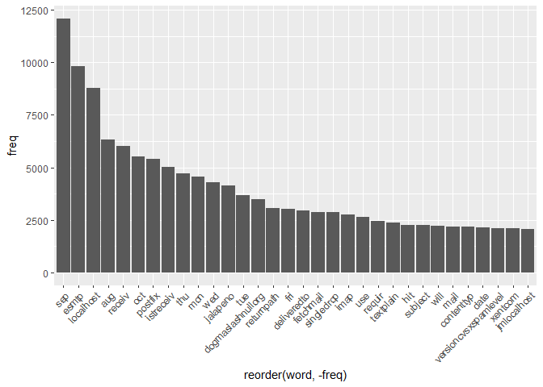

Word Frequency in Emails

```r
word_freq_bp <- ggplot(subset(word_freq, freq > 2000), aes(x=reorder(word, -freq), y =freq)) +
  geom_bar(stat = "identity") +
  theme(axis.text.x=element_text(angle=45, hjust=1))
word_freq_bp
```

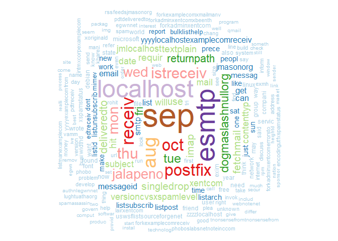

```r
set.seed(3000)
wordcloud(words = word_freq$word, freq = word_freq$freq, min.freq = 1,
          max.words=200, random.order=FALSE, rot.per=0.35,
          colors=brewer.pal(12, "Paired"))
```

## Text Classification

### Convert word frequency into logical value.

The term frequencies are replaced by Boolean presence/absence features for sentiment classification.

```r
convert_count <- function(x) {
  y <- ifelse(x > 0, 1,0)
  y <- factor(y, levels=c(0,1), labels=c("No", "Yes"))
  y
}

# Apply the convert_count function to get final training and testing DTMs
datasetNB <- apply(text_dtm, 2, convert_count)

dataset = as.data.frame(as.matrix(datasetNB))
```

```r
dataset$class = data$class
str(dataset$class)
```

```
##  Factor w/ 2 levels "HAM","SPAM": 1 1 1 1 1 1 1 2 1 2 ...
```

### Data Splitting Based on the Outcome

The function createDataPartition can be used to create balanced splits of the data. If the y argument to this function is a factor, the random sampling occurs within each class and should preserve the overall class distribution of the data. For example, to create a single 80/20% split of the data:

```r
set.seed(3000)  # caret function

train.set <- createDataPartition(dataset$class, p=.8, list = FALSE, times = 1)
head(train.set)
```

```
##      Resample1
## [1,]         1
## [2,]         2
## [3,]         3
## [4,]         4
## [5,]         5
## [6,]         7
```

### Create both train and test and check the proportion of the data split.

```r
dataTrain <- data[ train.set,]
dataTest <- data[ -train.set,]

prop.table(table(dataTrain$class))
```

```
##
##       HAM      SPAM
## 0.8357903 0.1642097
```

```r
prop.table(table(dataTest$class))
```

```
##
##       HAM      SPAM
## 0.8360656 0.1639344
```

## Model Fitting

### Analysis for this text classification

We will be building our model on 3 different Machine Learning algorithms which are `Random Forest, Naive Bayes and XGBoost: Extreme Gradient Boosting` for the purpose of deciding which perform the best.

### Random Forest Classifier

Random forest, like its name implies, consists of a large number of individual decision trees that operate as an ensemble. Each individual tree in the random forest spits out a class prediction and the class with the most votes becomes our model’s prediction.

[output not shown]

*The rf_classifier was able to accurately classify the text messages as ham and spam respectively with the class error of 0 which suggest that there is 100% accuracy of the model on the training set of observations.*

Making Predictions and evaluating the Random Forest Classifier.

We want to evaluate the model using the test_set and see if our model can match the 100% accuracy on this new set of data in comparison to the one obtained from the training set.

```r
# Predicting the Test set results
rf_pred = predict(rf_classifier, newdata = dataTest)

# Making the Confusion Matrix
confusionMatrix(table(rf_pred,dataTest$class))
```

```
## Confusion Matrix and Statistics
##
##
## rf_pred HAM SPAM
##    HAM  510    0
##    SPAM   0  100
##
##                Accuracy : 1
##                  95% CI : (0.994, 1)
##     No Information Rate : 0.8361
##     P-Value [Acc > NIR] : < 2.2e-16
##
##                   Kappa : 1
##
##  Mcnemar's Test P-Value : NA
##
##             Sensitivity : 1.0000
##             Specificity : 1.0000
##          Pos Pred Value : 1.0000
##          Neg Pred Value : 1.0000
##              Prevalence : 0.8361
##          Detection Rate : 0.8361
##    Detection Prevalence : 0.8361
##       Balanced Accuracy : 1.0000
##
##        'Positive' Class : HAM
##
```

*The Random Forest Classifier (rf_classifier) performed well on this data set as the model accuracy is 1.0 with a 95% CI of 0.994.*

### Naive Bayes Classifier

It is a Machine Learning model that is based upon the assumptions of conditional probability as proposed by Bayes’ Theorem. It is fast and easy.

```r
control <- trainControl(method="repeatedcv", number=10, repeats=3)
system.time( classifier_nb <- naiveBayes(dataTrain, dataTrain$class, laplace = 1,
                                         trControl = control,tuneLength = 7) )
```

```
##    user  system elapsed
##    4.81    0.00    4.81
```

Making Predictions and evaluating the Naive Bayes Classifier.

```r
nb_pred = predict(classifier_nb, type = 'class', newdata = dataTest)

confusionMatrix(nb_pred, dataTest$class)
```

```
## Confusion Matrix and Statistics
##
##           Reference
## Prediction HAM SPAM
##       HAM  510    0
##       SPAM   0  100
##
##                Accuracy : 1
##                  95% CI : (0.994, 1)
##     No Information Rate : 0.8361
##     P-Value [Acc > NIR] : < 2.2e-16
##
##                   Kappa : 1
##
##  Mcnemar's Test P-Value : NA
##
##             Sensitivity : 1.0000
##             Specificity : 1.0000
##          Pos Pred Value : 1.0000
##          Neg Pred Value : 1.0000
##              Prevalence : 0.8361
##          Detection Rate : 0.8361
##    Detection Prevalence : 0.8361
##       Balanced Accuracy : 1.0000
##
##        'Positive' Class : HAM
##
```

*Naive Bayes Classifier performed well on this data set as the model accuracy is 1.0 with a 95% CI of 0.994.*

### XGBoost: eXtreme Gradient Boosting

```r
test_split<-round(.25*dim(text_dtm)[1])

test_text<-text_dtm[1:test_split,]
train_text<-text_dtm[(test_split+1):dim(text_dtm)[1],]
```

```r
test_target<-data$target[1:test_split]
train_target<-data$target[(test_split+1):dim(data)[1]]
```

```r
xgb <- xgboost(data = as.matrix(train_text),
               label = as.vector(train_target),
               max.depth = 7, eta = 1,
               nthread = 2, nrounds = 2,
               objective = "binary:logistic")
```

```
## [23:34:23] WARNING: amalgamation/../src/learner.cc:1115: Starting in XGBoost 1.3.0, the default evaluation metric used with the objective 'binary:logistic' was changed from 'error' to 'logloss'. Explicitly set eval_metric if you'd like to restore the old behavior.
```

```r
xg_pred <- predict(xgb, as.matrix(test_text))
```

```r
# Convert probabilities to binary
xg_pred<- ifelse(xg_pred >0.5, 1,0)
```

```r
# Evaluate
confusionMatrix(data = factor(xg_pred, levels=c(1,0)),
                reference = factor(test_target, levels=c(1,0)),
                positive = "1", dnn = c("Prediction", "Actual"))
```

```
## Confusion Matrix and Statistics
##
##           Actual
## Prediction   1   0
##          1 126   0
##          0   0 637
##
##                Accuracy : 1
##                  95% CI : (0.9952, 1)
##     No Information Rate : 0.8349
##     P-Value [Acc > NIR] : < 2.2e-16
##
##                   Kappa : 1
##
##  Mcnemar's Test P-Value : NA
##
##             Sensitivity : 1.0000
##             Specificity : 1.0000
##          Pos Pred Value : 1.0000
##          Neg Pred Value : 1.0000
##              Prevalence : 0.1651
##          Detection Rate : 0.1651
##    Detection Prevalence : 0.1651
##       Balanced Accuracy : 1.0000
##
##        'Positive' Class : 1
##
```

### References:

- Naïve Bayes Classifier · UC Business Analytics R Programming Guide. (2018). Github.io. http://uc-r.github.io/naive_bayes
- Kuhn, M. (n.d.). 3 Pre-Processing | The caret Package. In topepo.github.io. Retrieved November 15, 2021, from https://topepo.github.io/caret/pre-processing.html#putting-it-all-together
- Index of /old/publiccorpus. (n.d.). Spamassassin.apache.org. https://spamassassin.apache.org/old/publiccorpus/

Source:

[GitHub](https://github.com/candrewxs/D607_Project4/blob/main/Project%204.Rmd) [RPubs](https://rpubs.com/blesned/HamSpam)